# Elon Musk vs. BTC

A google causal impact analysis between the Elon Musk's tweet and the Bitcoin price.

Posted by Sakiful Ahmed Saiyan on May 27, 2023

[figure not shown]

[figure not shown]

[figure not shown]

# **1 Introduction**

## 1.1 Case Study

[figure not shown]

To analyze the causal relationship between Musk's tweet and Bitcoin's price and what would be the alternative sceinario of the Bitcoin prices if Elon Musk did not make the tweet, we will employ the "Google Causal Impact" using Python.

## 1.2 Google Causal Impact

The "Google Causal Impact" is a statistical approach used to estimate the causal impact of a particular event on a target variable, while accounting for various other factors that may influence the outcome. It is based on Bayesian structural time series models and is particularly effective in evaluating the impact of stock/crypto price change, marketing campaigns, policy changes, or other interventions. Google Causal Impact package was initially developed for "R" by Google team, later the packege was imported to "python"

By using this technique, we can isolate the effect of Elon Musk's tweet on Bitcoin's price, controlling for other factors such as market trends, trading volume, and external events. The analysis will provide insights into the direct influence of the tweet on Bitcoin's price movement, allowing us to understand the magnitude and significance of the impact. And help to visualize the what-if scenario for the Bitcoin price.

# **2 Model Implementation**

## 2.1 Libraries, Dates, Data

- Import python libraries
- Set the data time-frame & stocks
- Import the stock datas

```python
import pandas as pd
import seaborn as sns
import matplotlib.pyplot as plt
import yfinance as yf
from causalimpact import CausalImpact
```

```python
training_start = "2021-04-12"
training_end = "2021-05-12"
treatment_start = "2021-05-13"
treatment_end = "2021-05-20"
end_stock = "2021-05-21"
```

```python
y_stock = ["BTC-USD"]
y = yf.download(y_stock,
                training_start,
                end_stock,
                interval="1d")
y.head()
```

```
[*********************100%***********************]  1 of 1 completed
```

| Date | Open | High | Low | Close | Adj Close | Volume |
| --- | --- | --- | --- | --- | --- | --- |
| 2021-04-12 | 60175.945312 | 61253.035156 | 59589.875000 | 59893.453125 | 59893.453125 | 51828688519 |
| 2021-04-13 | 59890.019531 | 63742.285156 | 59869.957031 | 63503.457031 | 63503.457031 | 69983454362 |
| 2021-04-14 | 63523.753906 | 64863.097656 | 61554.796875 | 63109.695312 | 63109.695312 | 77451779687 |
| 2021-04-15 | 63075.195312 | 63821.671875 | 62208.964844 | 63314.011719 | 63314.011719 | 60954381579 |
| 2021-04-16 | 63258.503906 | 63594.722656 | 60222.531250 | 61572.789062 | 61572.789062 | 84293007468 |

```python
y = y["Adj Close"].rename("BTC")
y.head(2)
```

```
Date
2021-04-12    59893.453125
2021-04-13    63503.457031
Name: BTC, dtype: float64
```

```python
X_stocks = ["MSFT", "NVDA", "AI", "EA", "SQ", "CRSP", "GOOG", "WMT"]
X = yf.download(X_stocks,
                training_start,
                end_stock,
                interval="1d")
X.head()
```

```
[*********************100%***********************]  8 of 8 completed
```

| Date | Adj Close AI | Adj Close CRSP | Adj Close EA | Adj Close GOOG | Adj Close MSFT | Adj Close NVDA | Adj Close SQ | Adj Close WMT | Close AI | Close CRSP | ... | Open SQ | Open WMT | Volume AI | Volume CRSP | Volume EA | Volume GOOG | Volume MSFT | Volume NVDA | Volume SQ | Volume WMT |
| --- | --- | --- | --- | --- | --- | --- | --- | --- | --- | --- | --- | --- | --- | --- | --- | --- | --- | --- | --- | --- | --- |
| 2021-04-12 | 59.889999 | 114.389999 | 139.680893 | 112.739502 | 250.827927 | 151.826202 | 265.200012 | 134.979538 | 59.889999 | 114.389999 | ... | 258.190002 | 140.070007 | 3111900 | 1080900 | 2058100 | 31318000 | 27148700 | 86932400 | 9051300 | 6241000 |
| 2021-04-13 | 63.009998 | 120.879997 | 140.332626 | 113.363503 | 253.356720 | 156.523056 | 273.230011 | 134.564331 | 63.009998 | 120.879997 | ... | 267.480011 | 139.800003 | 3297300 | 1352800 | 2105300 | 23310000 | 23837500 | 67621200 | 10561700 | 5799300 |
| 2021-04-14 | 68.459999 | 123.110001 | 139.838898 | 112.741997 | 250.514282 | 152.505051 | 258.399994 | 134.516068 | 68.459999 | 123.110001 | ... | 274.130005 | 139.119995 | 11721300 | 1914000 | 1424900 | 20220000 | 23070900 | 38550000 | 12486400 | 7308200 |
| 2021-04-15 | 66.500000 | 123.849998 | 140.984390 | 114.833000 | 254.346634 | 161.092590 | 263.079987 | 135.327118 | 66.500000 | 123.849998 | ... | 262.850006 | 139.399994 | 6223600 | 896300 | 1654300 | 27472000 | 25627500 | 59848000 | 8944400 | 7236800 |
| 2021-04-16 | 66.790001 | 118.559998 | 139.285889 | 114.888000 | 255.562057 | 158.849014 | 256.100006 | 135.761581 | 66.790001 | 118.559998 | ... | 263.239990 | 140.889999 | 2988000 | 1359200 | 2468400 | 22596000 | 24878600 | 33520800 | 8549300 | 8829500 |

5 rows × 48 columns

> 💡 Here in confounders (X) stocks we are excluding stoks related to crypto currency & Elon Musk for remove selection biases

```python
X = X["Adj Close"]
X.head(2)
```

| Date | AI | CRSP | EA | GOOG | MSFT | NVDA | SQ | WMT |
| --- | --- | --- | --- | --- | --- | --- | --- | --- |
| 2021-04-12 | 59.889999 | 114.389999 | 139.680893 | 112.739502 | 250.827927 | 151.826202 | 265.200012 | 134.979538 |
| 2021-04-13 | 63.009998 | 120.879997 | 140.332626 | 113.363503 | 253.356720 | 156.523056 | 273.230011 | 134.564331 |

```python
X.index = X.index.tz_localize(None)
```

```python
df = pd.concat([y,X],axis=1).dropna()
df.head()
```

| Date | BTC | AI | CRSP | EA | GOOG | MSFT | NVDA | SQ | WMT |
| --- | --- | --- | --- | --- | --- | --- | --- | --- | --- |
| 2021-04-12 | 59893.453125 | 59.889999 | 114.389999 | 139.680893 | 112.739502 | 250.827927 | 151.826202 | 265.200012 | 134.979538 |
| 2021-04-13 | 63503.457031 | 63.009998 | 120.879997 | 140.332626 | 113.363503 | 253.356720 | 156.523056 | 273.230011 | 134.564331 |
| 2021-04-14 | 63109.695312 | 68.459999 | 123.110001 | 139.838898 | 112.741997 | 250.514282 | 152.505051 | 258.399994 | 134.516068 |
| 2021-04-15 | 63314.011719 | 66.500000 | 123.849998 | 140.984390 | 114.833000 | 254.346634 | 161.092590 | 263.079987 | 135.327118 |
| 2021-04-16 | 61572.789062 | 66.790001 | 118.559998 | 139.285889 | 114.888000 | 255.562057 | 158.849014 | 256.100006 | 135.761581 |

## 2.2 Analysis

- Create training dataframe
- Apply "Differencing" technique to make the data stationery
- Visualize to check the correlation between "Treatment" and "Confounders"
- Dropp least correlated confounders. Here the minimum threshold is 0.4

```python
training_df = df[df.index <= training_end]
training_df.head()
```

| Date | BTC | AI | CRSP | EA | GOOG | MSFT | NVDA | SQ | WMT |
| --- | --- | --- | --- | --- | --- | --- | --- | --- | --- |
| 2021-04-12 | 59893.453125 | 59.889999 | 114.389999 | 139.680893 | 112.739502 | 250.827927 | 151.826202 | 265.200012 | 134.979538 |
| 2021-04-13 | 63503.457031 | 63.009998 | 120.879997 | 140.332626 | 113.363503 | 253.356720 | 156.523056 | 273.230011 | 134.564331 |
| 2021-04-14 | 63109.695312 | 68.459999 | 123.110001 | 139.838898 | 112.741997 | 250.514282 | 152.505051 | 258.399994 | 134.516068 |
| 2021-04-15 | 63314.011719 | 66.500000 | 123.849998 | 140.984390 | 114.833000 | 254.346634 | 161.092590 | 263.079987 | 135.327118 |
| 2021-04-16 | 61572.789062 | 66.790001 | 118.559998 | 139.285889 | 114.888000 | 255.562057 | 158.849014 | 256.100006 | 135.761581 |

```python
differencing = training_df.pct_change().dropna()
differencing.head()
```

| Date | BTC | AI | CRSP | EA | GOOG | MSFT | NVDA | SQ | WMT |
| --- | --- | --- | --- | --- | --- | --- | --- | --- | --- |
| 2021-04-13 | 0.060274 | 0.052095 | 0.056736 | 0.004666 | 0.005535 | 0.010082 | 0.030936 | 0.030279 | -0.003076 |
| 2021-04-14 | -0.006201 | 0.086494 | 0.018448 | -0.003518 | -0.005482 | -0.011219 | -0.025670 | -0.054277 | -0.000359 |
| 2021-04-15 | 0.003237 | -0.028630 | 0.006011 | 0.008192 | 0.018547 | 0.015298 | 0.056310 | 0.018111 | 0.006029 |
| 2021-04-16 | -0.027501 | 0.004361 | -0.042713 | -0.012047 | 0.000479 | 0.004779 | -0.013927 | -0.026532 | 0.003210 |
| 2021-04-19 | -0.094986 | -0.070220 | -0.029690 | -0.010067 | 0.002019 | -0.007671 | -0.034611 | -0.042054 | -0.006400 |

> 💡 In 90% of the cases time series datas are non stationary. So we are assuming this dataframe containing non stationary data

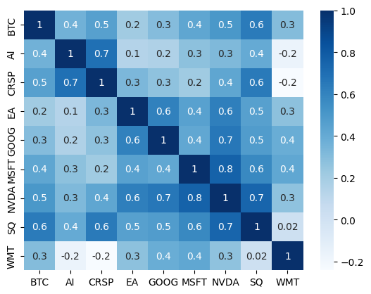

```python
sns.heatmap(data=differencing.corr(),
            annot=True,
            fmt=".1g",
            cmap="Blues")
plt.show()
```

```python
final_df = df.drop(columns=["EA", "GOOG", "WMT"])
final_df.head(2)
```

| Date | BTC | AI | CRSP | MSFT | NVDA | SQ |
| --- | --- | --- | --- | --- | --- | --- |
| 2021-04-12 | 59893.453125 | 59.889999 | 114.389999 | 250.827927 | 151.826202 | 265.200012 |
| 2021-04-13 | 63503.457031 | 63.009998 | 120.879997 | 253.356720 | 156.523056 | 273.230011 |

## 2.3 Model Creation

- Define Pre & Post period
- Create the impact model
- Summarise the model

```python
pre_period = [training_start,training_end]
post_period = [treatment_start, treatment_end]
```

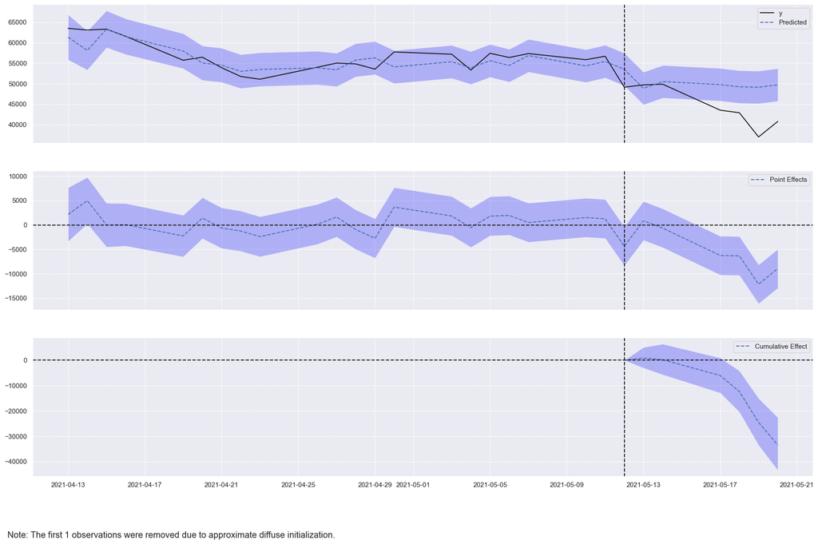

```python
impact = CausalImpact(data = final_df,
             pre_period = pre_period,
             post_period = post_period)

sns.set_theme()

impact.plot(figsize=(23,14))
plt.show()
```

> 💡 Since we are working with stock datas, we will not consider the "Cumelitive Effect" and only conside the "Relative Effect"

```python
print(impact.summary())
```

```
Posterior Inference {Causal Impact}
                          Average            Cumulative
Actual                    43971.47           263828.82
Prediction (s.d.)         49543.16 (885.73)  297258.94 (5314.37)
95% CI                    [47734.0, 51206.0] [286404.02, 307235.99]

Absolute effect (s.d.)    -5571.69 (885.73)  -33430.12 (5314.37)
95% CI                    [-7234.53, -3762.53][-43407.17, -22575.2]

Relative effect (s.d.)    -11.25% (1.79%)    -11.25% (1.79%)
95% CI                    [-14.6%, -7.59%]   [-14.6%, -7.59%]

Posterior tail-area probability p: 0.0
Posterior prob. of a causal effect: 100.0%

For more details run the command: print(impact.summary('report'))
```

## 2.4 Interpretation

The probability of obtaining this effect by chance alone, as indicated by the Bayesian one-sided tail-area probability (p-value), is very small at 0.0. Therefore, the causal effect can be considered statistically significant.

# **3 Conclusion**

By applying the Google Causal Impact we are able to prove there is a negative effect between the Elon Musk's Bitcoin tweet and the Bitcoin price fall. Understanding and analyzing causal relationships in cryptocurrency markets are crucial for investors, traders, policymakers, and researchers alike. By leveraging techniques like Google Causal Impact, we can gain a deeper understanding of the dynamics within these markets and make more informed decisions. This analysis serves as a reminder of the interconnectedness of social media, public figures, and the cryptocurrency landscape, and the potential implications of their interactions on market behavior.

Overall, the case study showcases the power of data analysis techniques like Google Causal Impact in studying and quantifying the impact of specific events or interventions on cryptocurrency prices. This knowledge can provide valuable insights for market participants and contribute to a more comprehensive understanding of the complex and dynamic nature of the cryptocurrency market.